# Creating images with R

Grumpy snorlax

Jeffery Ji

```css
p,h1,h2,h3,h4 {
  font-family: 'Lucida Sans', 'Lucida Sans Regular', 'Lucida Grande', 'Lucida Sans Unicode', Geneva, Verdana, sans-serif;
}
h1, h2, h3 {
  font-weight: bold;
}
h2, h3 {
  background-clip: text;
  background-image: linear-gradient(to right, lightblue, green);
  color: transparent;
}
html, body {
  background: linear-gradient(to right, aliceblue, lightblue);
}
img {
  border-radius: 0.4em;
  padding: 1em;
}
img:hover {
  background-color: #6ac5fe;
  border-radius: 0.4em;
  padding: 1em;
  transition: 500ms;
}
```

## Project requirements

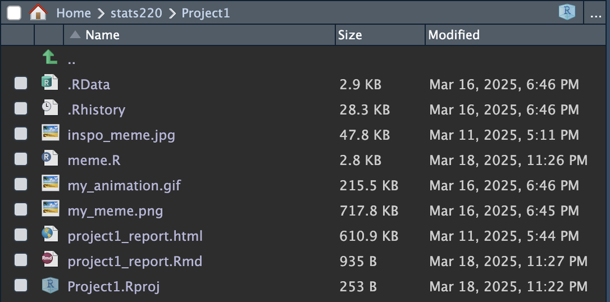

Project structure picture

Here is a [link to my stats220 GitHub page](https://github.com/jeffplays2005/stats220/tree/main)!

## Inspo meme

Inspirational meme:

[figure not shown]

The key components towards this meme is that there is a single image as the focus and a single line of text at the top annotating the meme.

## My meme

[figure not shown]

I changed the following in my meme:

- The image
- The text formatting, there are two lines of text, one at the top, one at the bottom.
- The text is also different but bases off of a similar idea in the inspirational meme.

## My animated meme

[figure not shown]

## Creativity

My project demonstrates creativity because of the following reasons:

- My animation is based off of 4 different frames.
  - Each of the frames have the same style as the other frames so there is a uniform style across the animation.
- My project changes the text and uses a header **and** a footer!
- My project uses a good sense of humor!!
- There is a creative usage of CSS in combination with this markdown to give a nice theme!
  - There is a gradient that has a similar theme to my inspirational image colours.
  - I change the font to a different one that looks a bit more “pokémon themed”
  - Images have a hover effect that applies a darker light-blue with a transition time.
  - Font colour changed for h2 and h3!

## Learning reflection

A very important idea I learnt is a lot of the crucial methods/functions that the `magick` library uses! For example, I learnt how to read, scale, annotate, and combine images! This is a very important skill as I had a project involving some basic image processing and R language seems very fast at doing this.

I’m just more curious on learning how fast R language actually runs, estimates of how fast image processing/editing is. The project I had in mind would preferably have a fast image editor that optimally doesn’t require a computationally expensive component to render quickly. I’m also quite curious as to if we have any more image processing, this was very fun and interesting to do!

## Appendix

Do not change, edit, or remove the `R` chunk included below.

If you are working within RStudio and within your Project1 RStudio project (check the top right-hand corner says “Project1”), then the code from the `meme.R` script will be displayed below.

This code needs to be visible for your project to be marked appropriately, as some of the criteria are based on this code being submitted.

```r
library(magick)

# inspiration meme url: https://www.reddit.com/r/pokemon/comments/nvsx3d/snorlax_meme/

# store the url
url <- "https://static1.thegamerimages.com/wordpress/wp-content/uploads/2023/08/pokemon-sleep-good-sleep-day-event-image.jpeg"
# fetch/read the image
meme_img <- image_read(url) %>%
  image_scale(500) # scale the image to an appropriate size
# create the top meme text
top_txt <- image_blank(width = 500, height = 109.5, color = "#FFFFFF") %>%
  image_annotate(text = "Snorlax's actual weekends:", color = "#000000", size = 35, gravity = "north") %>%
  image_annotate(text = "Good day", color = "#000000", size = 35, gravity = "south")
# create bottom text
bottom_txt <- image_blank(width = 500, height = 109.5, color = "#FFFFFF") %>%
  image_annotate(text = "Nap all day", color = "#000000", size = 70, gravity = "center")
# create a vector by combining all the text and image
img_vector <- c(top_txt, meme_img, bottom_txt)
meme <- image_append(img_vector, stack = TRUE) # append
# create my_meme.png
image_write(meme, "my_meme.png")

# frame 2
meme_img2 <- image_read("https://i.imgur.com/uPyWNDb.png") %>%
  image_scale(500)
# create new bottom text, top text is the same
bottom_txt2 <- image_blank(width = 500, height = 109.5, color = "#FFFFFF") %>%
  image_annotate(text = "Snack all night", color = "#000000", size = 60, gravity = "center")
img_vector2 <- c(top_txt, meme_img2, bottom_txt2)
frame2_img <- image_append(img_vector2, stack = TRUE)

# part 2, top text changes
top_txt2 <- image_blank(width = 500, height = 109.5, color = "#FFFFFF") %>%
  image_annotate(text = "Snorlax's actual weekends:", color = "#000000", size = 35, gravity = "north") %>%
  image_annotate(text = "Bad day", color = "#000000", size = 35, gravity = "south")

# frame 3
meme_img3 <- image_read("https://pm1.aminoapps.com/7070/d2096a671426b15248a7e8781b20ac65c72f7448r1-924-530v2_hq.jpg") %>%
  image_scale(500)
bottom_txt3 <- image_blank(width = 500, height = 109.5, color = "#FFFFFF") %>%
  image_annotate( text = "Mad all day", color = "#000000", size = 60, gravity = "center")
img_vector3 <- c(top_txt2, meme_img3, bottom_txt3)
frame3_img <- image_append(img_vector3, stack = TRUE)

# frame 4
meme_img4 <- image_read("https://hips.hearstapps.com/digitalspyuk.cdnds.net/16/19/1462804896-snorlax.jpg?crop=1xw:0.8888888888xh;center,top&resize=1200:*") %>%
  image_scale(500)
bottom_txt4 <- image_blank(width = 500, height = 109.5, color = "#FFFFFF") %>%
  image_annotate( text = "Calm all night", color = "#000000", size = 60, gravity = "center")
img_vector4 <- c(top_txt2, meme_img4, bottom_txt4)
frame4_img <- image_append(img_vector4, stack = TRUE)

all_frames <- c(meme, frame2_img, frame3_img, frame4_img)
meme_gif <- image_animate(all_frames, fps = 1)
# create my_animation.gif
image_write(meme_gif, "my_animation.gif")
```